# public data GO analysis

I have downloaded, mapped and counted reads over genes for 373 public RNA seq datasets. There are 2 biological replicates for each sample. The processing is detailed in a google drive markdown document https://drive.google.com/open?id=1mT7xdzzMvhn3HX5joY7xB5opygs2IZPr

The files SRRxxx_SRRxxx_counts_z_scores.txt_with_gene_name.txt contain all the genes (that had counts), so around 20,000 genes. For each gene there is a quantitated value per sample, along with a z score, p-value and absolute z-score. The z-scores and p-values have been calculated using an R script that runs the intensity difference test from SeqMonk and gives each gene a z-score depending on it’s position in the distribution.

1. Take the top 200 different genes and run them through a GO analysis.
2. Take genes that have a z-score higher than a certain threshold and re-run with these.

for i in SRR*gene_name.txt; do head -n 201 $i | cut -f1 - | tail -n 200 > ${i}_top_200.txt; done rename _counts_z_scores.txt_with_gene_name.txt_top_200.txt _top_200.txt *top_200.txt

```r
library("devtools")
load_all("C:/Users/bigginsl/Documents/GOcategoryStats")
```

```
Loading GOcategoryStats
```

## The 200 genes from each pair of samples that have the highest z-scores

```r
files <- list.files(path = "D:/projects/biases/public_data/top_200", pattern = "top_200.txt", full.names = TRUE)
top200 <- lapply(files, function(x) scan(x, what = "character"))
```

There are 373 sets of genes here so I don’t want to examine each of the gene lists. I’ll run them through a GO overrepresentation analysis.

```r
go_results <- overrep_test(all_go_categories, top200[[1]], bg_genes)
head(go_results)

all_go_results <- lapply(top200, function(query){
  overrep_test(all_go_categories, query, bg_genes)
  })
# took 7-8 mins to run for 373 datasets
```

[output not shown]

```r
all_sig_categories <- unlist(sapply(all_go_results, rownames))
tabled_categories <- table(all_sig_categories)
ordered_categories <- tabled_categories[order(tabled_categories, decreasing = TRUE)]
filename <- paste0("GO_summary_", length(top200), "_datasets.txt" )
write.table(x = ordered_categories, "GO_summary.txt", quote = FALSE, row.names = FALSE)
```

Now we could do with some stats to pick a cutoff for the number of times a category appears. Let’s just select an arbitrary value of 50 for now….

## Create a dataset that contains these suspect set of categories

```r
save(suspects_top200, file = "/data/suspects_top200.rda")
```

[output not shown]

Have a quick look at the genes in the top categories

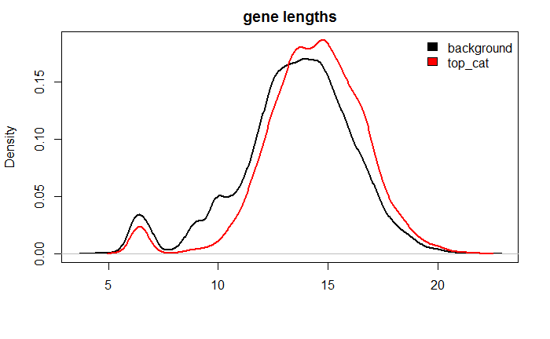

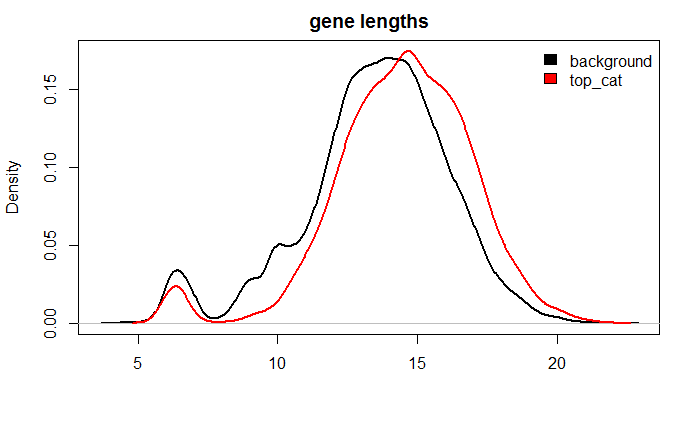

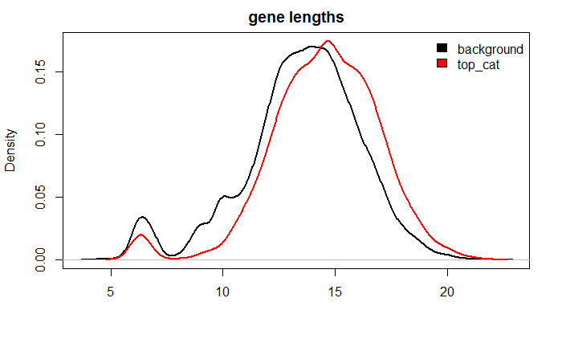

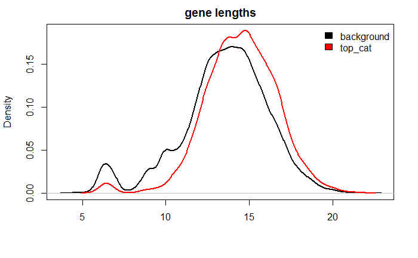

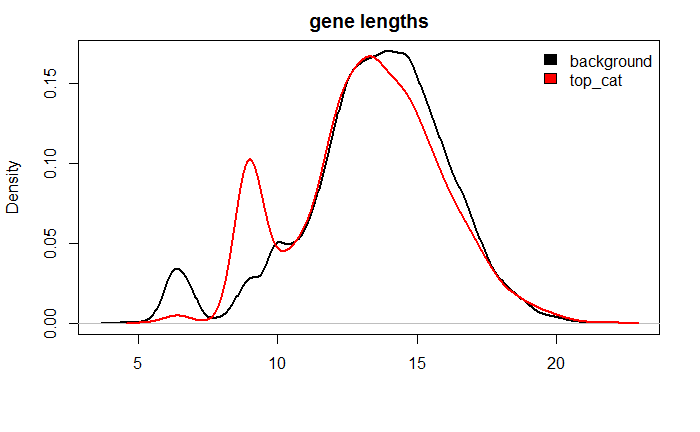

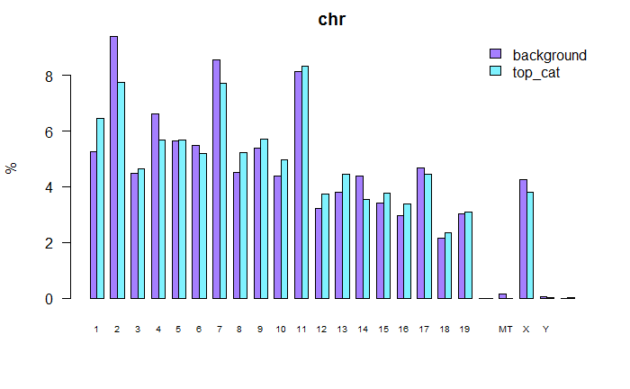

use awk to filter in unix `echo "" > z5.txt for i in *_gene_name.txt; do awk '$7>5 {print $1}' $i >> z5.txt ; done`

This would work in a different way as there could be wildly varying numbers of genes per dataset. This would be more of a case of getting a list of suspect genes rather than suspect categories, and then maybe generating a set of suspect categories from the genes.

```r
zfile <- "D:/projects/biases/public_data/top_zscores/z5.txt"
z5 <- scan(zfile, what = "character")

x_ordered <- table(z5)[order(table(z5), decreasing = TRUE)]


df <- data.frame(x_ordered)
colnames(df) <- c("gene_name", "count")
```